# STA 5207: Homework 1

Due: Friday, January 19th by 11:59 PM

Include your R code in an R chunks as part of your answer. In addition, your written answer to each exercise should be self-contained so that the grader can determine your solution without reading your code or deciphering its output.

## Exercise 1 (Exploratory Data Analysis (EDA) for `Diabetes` Data) [70 points]

For this exercise, we will use the `diabetes` dataset from the `faraway` package, which is the package for the recommend textbook for this course *Linear Models with R* by Julian J. Faraway.

1. (5 points) Install and load the `faraway` package. **Do not** include the installation command in your .Rmd file. (If you do it will install the package every time you knit your file.). **Do** include the command to load the package into your environment in an `R` chunk that is not executed as you answer to this question below.

   ```r
   library(faraway)
   data("diabetes")
   ```

2. (9 points) How many observations are in the `diabetes` dataset? How many variables? Who are the individuals in this dataset?

   ```r
   nrow(diabetes)
   ```

   ```
   ## [1] 403
   ```

   ```r
   ncol(diabetes)
   ```

   ```
   ## [1] 19
   ```

   There are 403 observations in the diabetes dataset, with 19 variables. The individuals in the dataset are people who have participated in a study to take multiple tests, glycosated hemoglobin being a key diagnosing factor for diabetes.
3. (9 points) How many individuals have HDL levels (High Density Lipoprotein) that are missing, that is, have a value of `NA`? What are the row numbers of the missing individuals? What is the mean HDL level (High Density Lipoprotein) of individuals in this sample?

   **Hint**: The mean should be calculated with `NA` values removed. Use `?mean` to determine an argument that removes missing values before calculating the mean.

   ```r
   sum(is.na(diabetes$hdl))
   ```

   ```
   ## [1] 1
   ```

   ```r
   which(is.na(diabetes$hdl))
   ```

   ```
   ## [1] 28
   ```

   ```r
   mean(diabetes$hdl, na.rm = TRUE)
   ```

   ```
   ## [1] 50.44527
   ```

   There is only 1 HDL level that is missing, which occurs in row 28 of the dataset. After removing this row, the mean is 50.45.
4. (5 points) What is the standard deviation of total cholesterol of individuals in this sample after removing missing values?

   **Hint**: The standard deviation should be calculated with `NA` values removed. Use `?sd` to determine an argument that removes missing values before calculating the standard deviation.

   ```r
   sd(diabetes$chol, na.rm = TRUE)
   ```

   ```
   ## [1] 44.44556
   ```

   ```r
   range(diabetes$age)
   ```

   ```
   ## [1] 19 92
   ```

   The participants in this sample range from the age of 19 and 92.
6. (6 points) What is the mean HDL of males in this sample?

   ```r
   mean(diabetes$hdl[diabetes$gender == "male"], na.rm = TRUE)
   ```

   ```
   ## [1] 48.125
   ```

   The mean HDL of males is 48.13.
7. (10 points) Create a scatter plot of HDL (y-axis) vs weight (x-axis). Use a non-default color for the points. Also, be sure to give the plot a title and label the axes appropriately. Based on the scatter plot, does there seem to be a relationship between the two variables? Briefly explain.

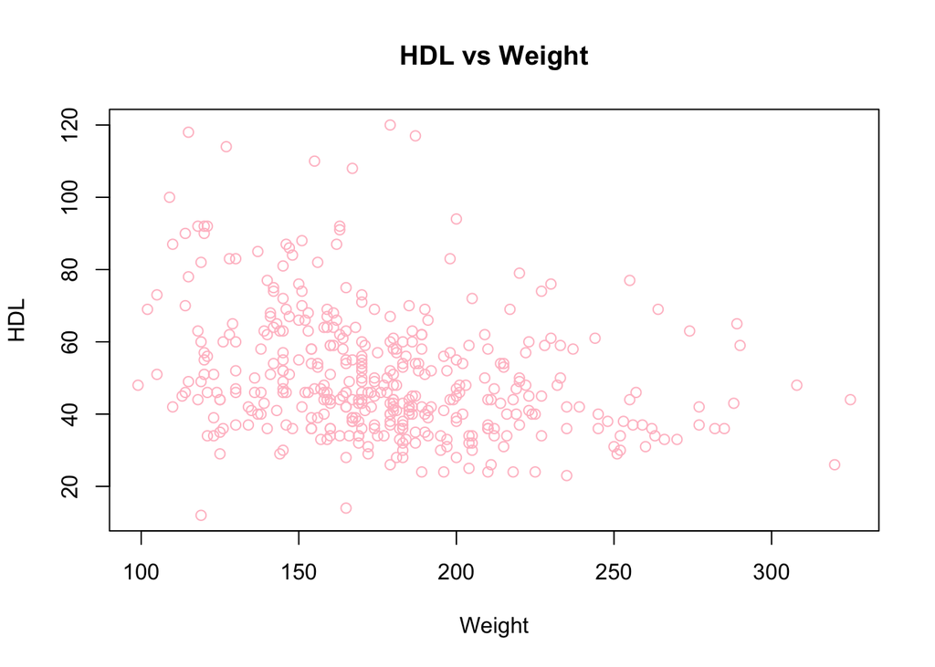

   ```r
   plot(diabetes$weight, diabetes$hdl, col = "pink", main = "HDL vs Weight", xlab = "Weight", ylab = "HDL")
   ```

   Based on the scatter plot, it seems that there is no significant relationship, except for that people at a lower weight seem to have a much higher HDL than those of the higher weight.
8. (10 points) Create a scatter plot of total cholesterol (y-axis) vs weight (x-axis). Use a non-default color for the points. Also, be sure to give the plot a title and label the axes appropriately. Based on the scatter plot, does there seem to be a relationship between the two variables? Briefly explain.

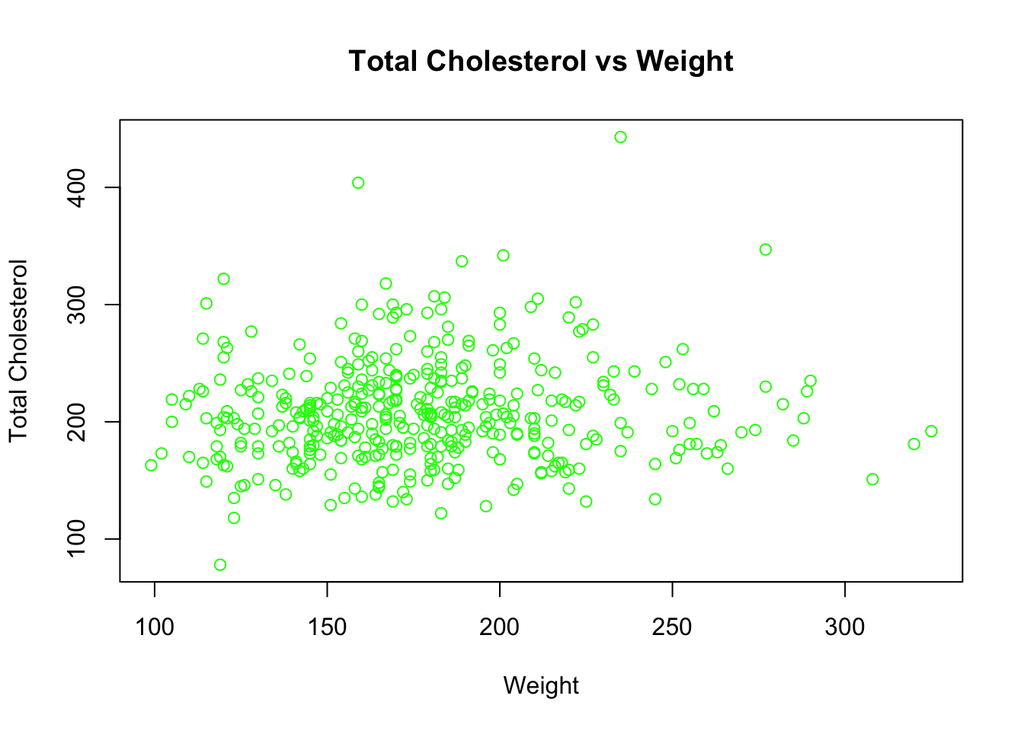

   ```r
   plot(diabetes$weight, diabetes$chol, col = "green", main = "Total Cholesterol vs Weight", xlab = "Weight", ylab = "Total Cholesterol")
   ```

   There is no significant relationship between weight and total cholesterol in the scatter plot. All of them seem to range between 100 and 300, with some outliers.
9. (10 points) Create side-by-side boxplots for HDL by gender. Use non-default colors for the plot. Also, be sure to give the plot a title and label the axes appropriately. Based on the boxplot, does there seem to be a difference between HDL level and gender? Briefly explain.

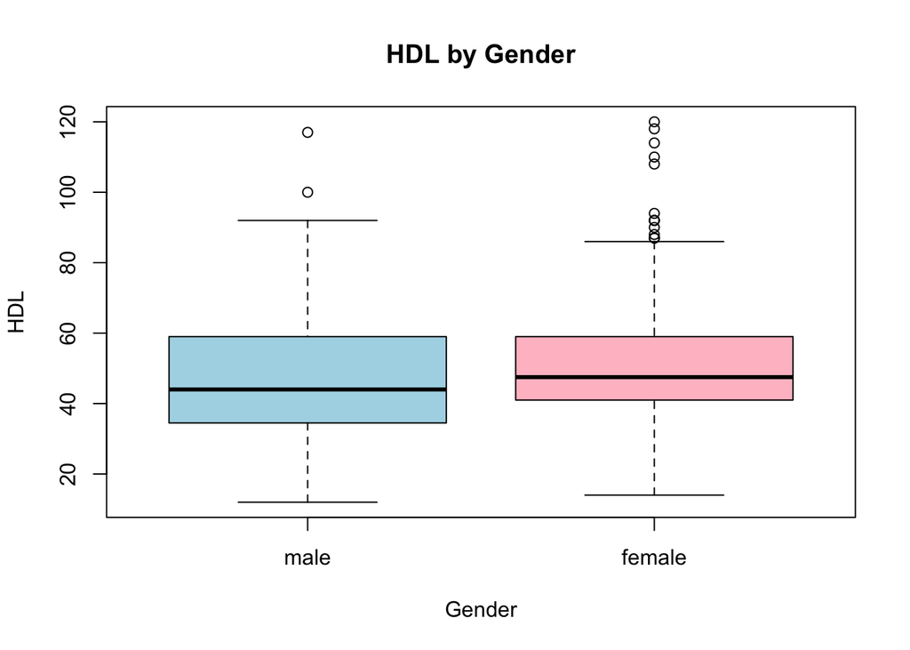

   ```r
   boxplot(hdl ~ gender, data = diabetes, col = c("lightblue", "pink"), main = "HDL by Gender", xlab = "Gender", ylab = "HDL")
   ```

## Exercise 2 (EDA for the `Salary` Dataset) [30 points]

This exercise will use the `hitters` data set, which you can find in `hitters.csv` on Canvas. This is a version of the `Hitters` data set from the `ISLR2` package with missing observations removed. The data set contains 132 observations of Major League Baseball (MLB) players from the 1986 and 1987 seasons. The data set contains the following 20 variables

- `AtBat`: Number of times at bat in 1986
- `Hits`: Number of hits in 1986
- `HmRuns`: Number of home runs in 1986
- `Runs`: Number of runs in 1986
- `RBI`: Number of runs batted in in 1986
- `Walks`: Number of walks in 1986
- `Years`: Number of years in the major leagues
- `CAtBat`: Number of times at bat during his career
- `CHits`: Number of hits during his career
- `CHmRun`: Number of home runs during his career
- `CRuns`: Number of runs during his career
- `CRBI`: Number of runs batted in during his career
- `CWalks`: Number of walks during his career
- `League`: The player’s league. (League = 1 for American, League = 0 for National)
- `Division`: The player’s division. (Division = 1 for West, Division = 0 for East)
- `PutOuts`: Number of put outs in 1986
- `Assists`: Number of assists in 1986
- `Errors`: Number of errors in 1986
- `Salary`: 1987 annual salary on opening day in thousands of dollars
- `NewLeague`: The player’s league at the beginning of 1987 (League = 1 for National, League = 0 for American)
1. (10 points) Create a histogram of `Salary`. Do not modify R’s default bin selection. Be sure to give the plot a title and label the axes appropriately. Describe the shape of the histogram and how it relates to the distribution of player’s salary in the MLB.

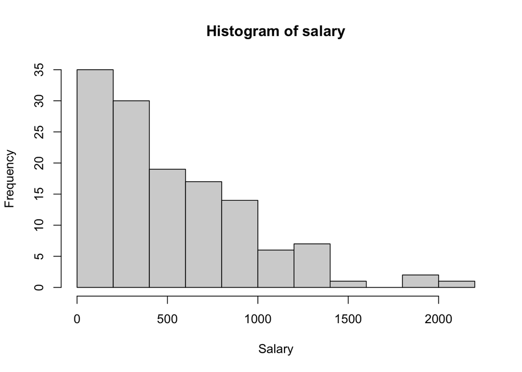

   ```r
   hist(salary, xlab = "Salary")
   ```

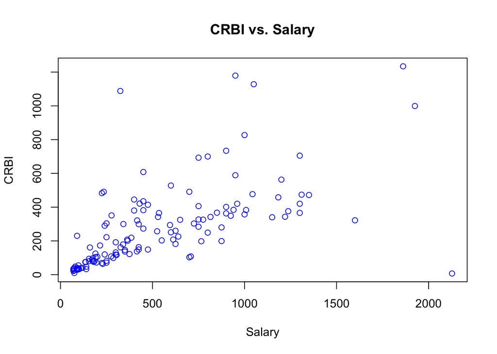

   ```r
   plot(hitters$Salary, hitters$CRBI, col = "blue", xlab = "Salary", ylab = "CRBI", main = "CRBI vs. Salary")
   ```

   There seems to be a relationship between CRBI and Salary. as the CRBI increases the salary also increases. It is hard to tell if this relationship is linear or exponential. There are a few outliers which would argue against this, such as the player with a 0 CRBI and a salary over $2,000,000, as well as the players with extremely high CRBI with a low salary.
3. (10 points) Create side-by-side boxplots for Salary by league. Use non-default colors for the plot. Also, be sure to give the plot a title and label the axes appropriately. Based on the boxplot, does there seem to be a difference between Salary by league? Briefly explain.

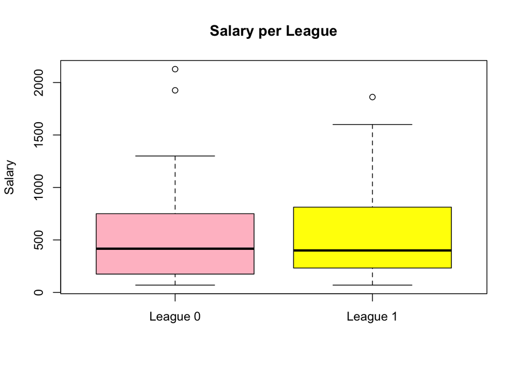

   ```r
   league1 = hitters[hitters$NewLeague == "1",]
   league0 = hitters[hitters$NewLeague == "0",]
   boxplot(league0$Salary,league1$Salary,
           main = "Salary per League",
           ylab = "Salary",
           names = c("League 0", "League 1"), col = c("pink","yellow"))
   ```